# Study on Worldwide CO2 emissions

## Exploratory Data Analysis

Lets see how CO2 emissions, Gross Domestic product which portrays economic growth, Urbanization and Human Development are distributed between countries

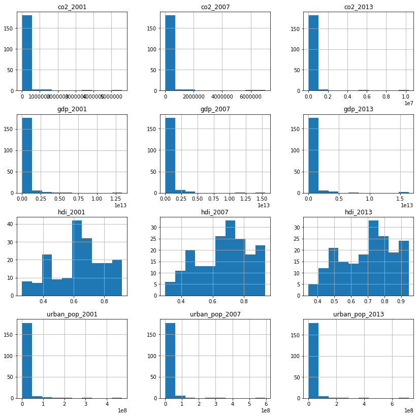

```python
df.hist(figsize= (14,14));
```

### Inference from Histogram

All the parameters had a skewed histogram apart from Human Developmoent Index. Skewed Histograms for CO2 emissions denote that fewer countries are responsible for the highest CO2 emissions.

Similar observations are found for Urban population and GDP shows that few countries contribute the highest for each parameter

### Whether there has been an increase in worlwide emissions of CO2?

The mean CO2 emissions for the study year has been plotted to evaluate the variation of CO2 emissions for each year

```python
# Mean CO2 emissions for each year

mean_co2_2001=df['co2_2001'].mean()
mean_co2_2007=df['co2_2007'].mean()
mean_co2_2013=df['co2_2013'].mean()
```

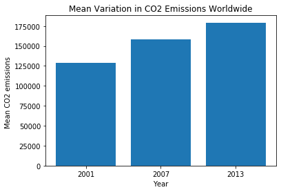

```python
# Bar Chart to visualise the variation of CO2 emissions over the years

locations = [1, 2,3]
heights = [mean_co2_2001, mean_co2_2007,mean_co2_2013]
labels = ['2001', '2007', '2013']
plt.bar(locations, heights, tick_label=labels)
plt.title('Mean Variation in CO2 Emissions Worldwide')
plt.xlabel('Year')
plt.ylabel('Mean CO2 emissions ');
```

#### Inference: The Above plot shows an increase in the Total CO2 emissions worldwide between 2001 and 2013

```python
# Finding the country with Lowest CO2 emission
min_co2_2013=df['co2_2013'].min()
```

```python
# Country with lowest CO2 Emission
df[df['co2_2013']==min_co2_2013]
```

|  | country | gdp_2001 | gdp_2007 | gdp_2013 | urban_pop_2001 | urban_pop_2007 | urban_pop_2013 | co2_2001 | co2_2007 | co2_2013 | hdi_2001 | hdi_2007 | hdi_2013 |
| --- | --- | --- | --- | --- | --- | --- | --- | --- | --- | --- | --- | --- | --- |
| 96 | Liechtenstein | 2.700000e+09 | 3.380000e+09 | 5.294710e+11 | 5020.0 | 5150.0 | 5290.0 | 128884.869565 | 62.3 | 51.3 | 0.868 | 0.893 | 0.912 |

```python
# Finding the country with highest CO2 emission
max_co2_2013=df['co2_2013'].max()
```

```python
# Country with highest CO2 Emission
df[df['co2_2013']==max_co2_2013]
```

|  | country | gdp_2001 | gdp_2007 | gdp_2013 | urban_pop_2001 | urban_pop_2007 | urban_pop_2013 | co2_2001 | co2_2007 | co2_2013 | hdi_2001 | hdi_2007 | hdi_2013 |
| --- | --- | --- | --- | --- | --- | --- | --- | --- | --- | --- | --- | --- | --- |
| 35 | China | 5.970000e+12 | 1.090000e+13 | 1.570000e+13 | 472000000.0 | 596000000.0 | 720000000.0 | 3490000.0 | 7030000.0 | 10300000.0 | 0.6 | 0.672 | 0.723 |

### Inference

- Country with the lowest CO2 emissions- Liechtenstein
- Country with the Highest CO2 Emissions- China

```python
# Adding a columns 'diff_co2' to analyze the inccrease or decrease in CO2 emissions

df['diff_co2']=df['co2_2013']-df['co2_2001']
```

[figure not shown]

```python
# Histogram for difference in CO2 emissions


import matplotlib.pyplot as plot
plot.hist(df['diff_co2'],density= False,  bins=10) ;
plot.axis() ;
plot.xlabel('Bins');
plot.ylabel('Difference in CO2 Emissions');
plot.title('Histogram for Variation in CO2 Emissions between 2007 and 2013')
```

```python
# Finding the country with Lowest variation of CO2 emission between 2007 and 2013
min_co2_diff=df['diff_co2'].min()
```

```python
# Country with lowest variation of CO2 emission between 2007 and 2013
df[df['diff_co2']==min_co2_diff]
```

|  | country | gdp_2001 | gdp_2007 | gdp_2013 | urban_pop_2001 | urban_pop_2007 | urban_pop_2013 | co2_2001 | co2_2007 | co2_2013 | hdi_2001 | hdi_2007 | hdi_2013 | diff_co2 |
| --- | --- | --- | --- | --- | --- | --- | --- | --- | --- | --- | --- | --- | --- | --- |
| 178 | United States | 1.330000e+13 | 1.550000e+13 | 1.640000e+13 | 226000000.0 | 242000000.0 | 257000000.0 | 5600000.0 | 5790000.0 | 5160000.0 | 0.887 | 0.905 | 0.916 | -440000.0 |

```python
# Finding the country with Highest variation of CO2 emission between 2007 and 2013
max_co2_diff=df['diff_co2'].max()
```

```python
# Country with Highest variation of CO2 emission between 2007 and 2013
df[df['diff_co2']==max_co2_diff]
```

|  | country | gdp_2001 | gdp_2007 | gdp_2013 | urban_pop_2001 | urban_pop_2007 | urban_pop_2013 | co2_2001 | co2_2007 | co2_2013 | hdi_2001 | hdi_2007 | hdi_2013 | diff_co2 |
| --- | --- | --- | --- | --- | --- | --- | --- | --- | --- | --- | --- | --- | --- | --- |
| 35 | China | 5.970000e+12 | 1.090000e+13 | 1.570000e+13 | 472000000.0 | 596000000.0 | 720000000.0 | 3490000.0 | 7030000.0 | 10300000.0 | 0.6 | 0.672 | 0.723 | 6810000.0 |

### More about the variation of CO2 emissions worldwide

```python
df.diff_co2.describe()
```

```
count    1.870000e+02
mean     5.044999e+04
std      5.055229e+05
min     -4.400000e+05
25%      2.750000e+01
50%      1.300000e+03
75%      8.815000e+03
max      6.810000e+06
Name: diff_co2, dtype: float64
```

### How have Economic Growth, Urbanization and Human Development have contributed to CO2 emissions worldwide?

This section tries to find out the impact that CO2 emissions have with respect to GDP, Urban Population Human Development Index

### Relation between CO2 emissions and Gross Domestic Product

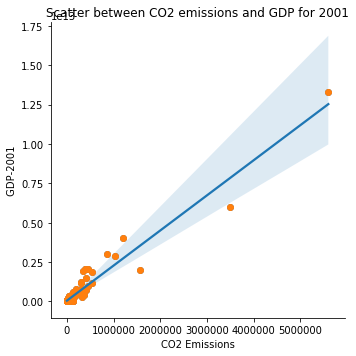

```python
# Scatter Plot for the year 2001 betwwen CO2 emissions and GDP

sns.lmplot(x='co2_2001',y='gdp_2001',data=df,fit_reg=True)

plt.scatter(df['co2_2001'], df['gdp_2001'])
plt.title('Scatter between CO2 emissions and GDP for 2001')
plt.xlabel('CO2 Emissions')
plt.ylabel(' GDP-2001 ')
plt.show()
```

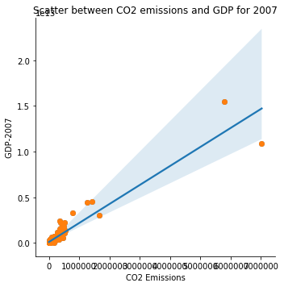

```python
# Scatter Plot for the year 2007 betwwen CO2 emissions and GDP


sns.lmplot(x='co2_2007',y='gdp_2007',data=df,fit_reg=True)
plt.scatter(df['co2_2007'], df['gdp_2007'])
plt.title('Scatter between CO2 emissions and GDP for 2007')
plt.xlabel('CO2 Emissions')
plt.ylabel(' GDP-2007 ')
plt.show()
```

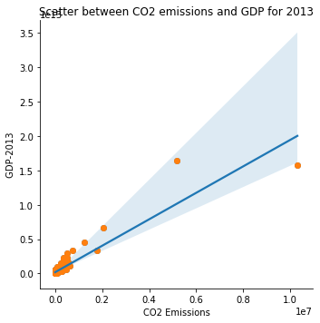

```python
# Scatter Plot for the year 2013 betwwen CO2 emissions and GDP


sns.lmplot(x='co2_2013',y='gdp_2013',data=df,fit_reg=True)

plt.scatter(df['co2_2013'], df['gdp_2013'])
plt.title('Scatter between CO2 emissions and GDP for 2013')
plt.xlabel('CO2 Emissions')
plt.ylabel(' GDP-2013 ')
plt.show()
```

#### Inference

There exist a positive correlation between CO2 emissions and the Gross Domestic Product of a country. The scatter between the two parameters plotted above visually depicts a positive correlatioin. Another notable feature of the plot is the two extreme dots at the top right corner of each plots. These are countries having the highest CO2 emissions and highest GDP. One of them is China

### Relation between CO2 emissions and Urban Population

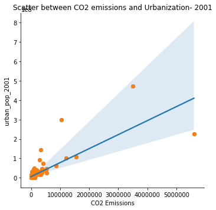

```python
# Scatter Plot for the year 2001 betwwen CO2 emissions and Urban Population


sns.lmplot(x='co2_2001',y='urban_pop_2001',data=df,fit_reg=True);

plt.scatter(df['co2_2001'], df['urban_pop_2001'])
plt.title('Scatter between CO2 emissions and Urbanization- 2001')
plt.xlabel('CO2 Emissions')
plt.ylabel(' urban_pop_2001 ')
plt.show()
```

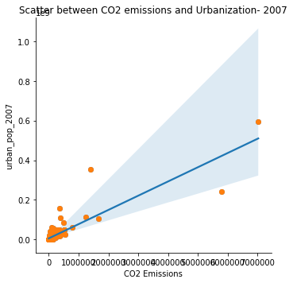

```python
# Scatter Plot for the year 2007 betwwen CO2 emissions and Urban Population


sns.lmplot(x='co2_2007',y='urban_pop_2007',data=df,fit_reg=True);

plt.scatter(df['co2_2007'], df['urban_pop_2007'])
plt.title('Scatter between CO2 emissions and Urbanization- 2007')
plt.xlabel('CO2 Emissions')
plt.ylabel(' urban_pop_2007 ')
plt.show()
```

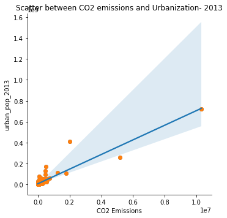

```python
# Scatter Plot for the year 2013 betwwen CO2 emissions and Urban Population


sns.lmplot(x='co2_2013',y='urban_pop_2013',data=df,fit_reg=True);

plt.scatter(df['co2_2013'], df['urban_pop_2013'])
plt.title('Scatter between CO2 emissions and Urbanization- 2013')
plt.xlabel('CO2 Emissions')
plt.ylabel(' urban_pop_2013 ')
plt.show()
```

```python
# Finding the country with Highest urban Population in 2013
max_urban_pop_2013=df['urban_pop_2013'].max()
```

```python
# Finding the country with Highest urban Population in 2013
df[df['urban_pop_2013']==max_urban_pop_2013]
```

|  | country | gdp_2001 | gdp_2007 | gdp_2013 | urban_pop_2001 | urban_pop_2007 | urban_pop_2013 | co2_2001 | co2_2007 | co2_2013 | hdi_2001 | hdi_2007 | hdi_2013 | diff_co2 |
| --- | --- | --- | --- | --- | --- | --- | --- | --- | --- | --- | --- | --- | --- | --- |
| 35 | China | 5.970000e+12 | 1.090000e+13 | 1.570000e+13 | 472000000.0 | 596000000.0 | 720000000.0 | 3490000.0 | 7030000.0 | 10300000.0 | 0.6 | 0.672 | 0.723 | 6810000.0 |

### Inference

Positive Correlation exist between CO2 emissions and Urban Population.

### Relation between CO2 emissions and Human Development Index

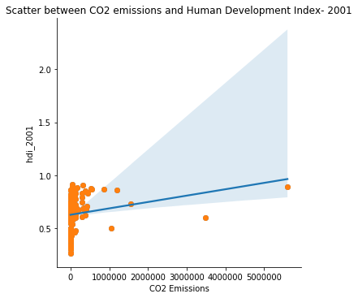

```python
# Scatter Plot for the year 2001 betwwen CO2 emissions and Human Development Index


sns.lmplot(x='co2_2001',y='hdi_2001',data=df,fit_reg=True);

plt.scatter(df['co2_2001'], df['hdi_2001'])
plt.title('Scatter between CO2 emissions and Human Development Index- 2001')
plt.xlabel('CO2 Emissions')
plt.ylabel(' hdi_2001 ')
plt.show()
```

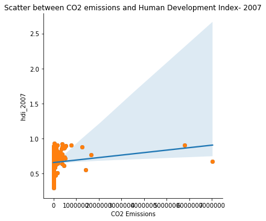

```python
# Scatter Plot for the year 2007 betwwen CO2 emissions and Human Development Index


sns.lmplot(x='co2_2007',y='hdi_2007',data=df,fit_reg=True);

plt.scatter(df['co2_2007'], df['hdi_2007'])
plt.title('Scatter between CO2 emissions and Human Development Index- 2007')
plt.xlabel('CO2 Emissions')
plt.ylabel(' hdi_2007 ')
plt.show()
```

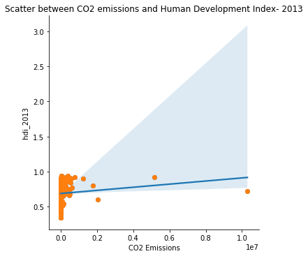

```python
# Scatter Plot for the year 2013 betwwen CO2 emissions and Human Development Index

sns.lmplot(x='co2_2013',y='hdi_2013',data=df,fit_reg=True);
plt.scatter(df['co2_2013'], df['hdi_2013'])
plt.title('Scatter between CO2 emissions and Human Development Index- 2013')
plt.xlabel('CO2 Emissions')
plt.ylabel(' hdi_2013 ')
plt.show()
```

```python
# Finding the country with Highest Human Development Index in 2013
max_hdi_2013=df['hdi_2013'].max()
```

```python
# Finding the country with Highest Human Development Index in 2013
df[df['hdi_2013']==max_hdi_2013]
```

|  | country | gdp_2001 | gdp_2007 | gdp_2013 | urban_pop_2001 | urban_pop_2007 | urban_pop_2013 | co2_2001 | co2_2007 | co2_2013 | hdi_2001 | hdi_2007 | hdi_2013 | diff_co2 |
| --- | --- | --- | --- | --- | --- | --- | --- | --- | --- | --- | --- | --- | --- | --- |
| 123 | Norway | 2.630000e+11 | 3.070000e+11 | 3.120000e+11 | 3450000.0 | 3680000.0 | 4080000.0 | 41900.0 | 45100.0 | 58200.0 | 0.916 | 0.936 | 0.945 | 16300.0 |

### Inference

Correlation between CO2 emissions and Human development INdex was also positive but had a different nature compared to the other two relations

# Conclusion

#### Research Question 1: Whether thera have been an increase in CO2 emissions worldwide?

Yes, There has been an increase in the total emissions of CO2 over the study period.

#### Research Question 2: How does economic growth, urbanization and Human development contributes to CO2 emissions

The relation between economic growth, human development and urbanisation were studied. The study shows that CO2 emissions have a high degree of correlation with the Gross Domestic Product which represents economic growth and Urban Population of each country. These observations are only based on the scatter plots prepared. Further degree od correlation needs to be studied further. The relation between CO2 emissions and Human Development Index has not been clearly visible.

#### Limitation

The study is limited to analysing the trend in CO2 and the correlation between CO2 emissions and few other parameters. CO2 emissions may be depended on many other factors which has to be studied well. CO2 emissions are also dependent on population of the particular country. This factor, if taken into consideration may alter the best performing and worst performing countries for CO2 emissions.